# GSS Stats 722 Final

2022-11-26

Dear Nico,

I hope you enjoy this to some extent.

1. *Estimand*: What is the total effect of party identification on people’s trust in cops?

```r
library(gssr)
library(rethinking)
library(tidybayes.rethinking)
library(tidybayes)
library(tidyverse)
# get data
d <- gss_get_yr(2006)
```

```
## Fetching: https://gss.norc.org/documents/stata/2006_stata.zip
```

```r
dd <- d %>%
  select(acqprisn, partyid, trtcops, race, sex, rincome) %>%
  drop_na()

# clean data

dd <- dd %>%
  filter(partyid != 7) %>% # simplifying, taking out "other"
  filter(race != 3) %>%
  # simplifying for my analysis... having the other made it harder for me to
  # decide priors, again... not sure I can do this but for my practice it made
  # it easier for me to understand
  mutate(female = if_else(sex == 2, 1L, 0L),
         partyid = case_when(
            # I changed it to be this way from doing it where I
           # just add one because I wanted to see if it would help me when
           # trying to make a plot...
           # update, it did not,  lol
           partyid == 0 ~ 1,
           partyid == 1 ~ 2,
           partyid == 2 ~ 3,
           partyid == 3 ~ 4,
           partyid == 4 ~ 5,
           partyid == 5 ~ 6,
           partyid == 6 ~ 7,
         ),
         income = case_when(
         rincome == 1~ 1,
         rincome == 2 ~ 2,
         rincome == 3 ~ 3,
         rincome == 4 ~ 4,
         rincome == 5 ~ 5,
         rincome == 6 ~ 6,
         rincome == 7 ~ 7,
         rincome == 8~ 8,
         rincome == 9 ~ 9,
         rincome == 10 ~ 10,
         rincome == 11 ~ 11,
         rincome == 12 ~ 12,
         ),
         black = if_else(race == 2, 1L, 0L),
         trtcops = if_else(trtcops == 1, 0L, 1L)) %>%
  select(-race, - sex, -rincome)
# I wasn't sure how to clean income data since they data is not asked
# in a way that gives numbers back of actual income

glimpse(dd)
```

```
## Rows: 308
## Columns: 6
## $ acqprisn <dbl+lbl> 1, 1, 1, 1, 1, 1, 1, 1, 1, 2, 1, 1, 1, 2, 2, 1, 2, 1, 1, …
## $ partyid  <dbl> 1, 4, 4, 4, 6, 1, 4, 3, 4, 6, 5, 1, 6, 7, 1, 1, 5, 3, 2, 4, 6…
## $ trtcops  <int> 1, 0, 0, 0, 0, 0, 0, 0, 1, 1, 0, 1, 1, 1, 0, 0, 1, 1, 1, 1, 0…
## $ female   <int> 1, 1, 1, 1, 0, 1, 0, 1, 0, 0, 0, 0, 1, 1, 0, 1, 0, 1, 0, 0, 1…
## $ income   <dbl> 12, 4, 7, 12, 12, 12, 12, 6, 12, 12, 11, 12, 11, 7, 12, 12, 1…
## $ black    <int> 0, 0, 1, 0, 0, 1, 0, 0, 1, 0, 0, 0, 0, 0, 0, 0, 0, 0, 0, 0, 0…
```

```r
View(dd)
```

2. Create DAG.

```r
library(dagitty)
library(ggdag)
```

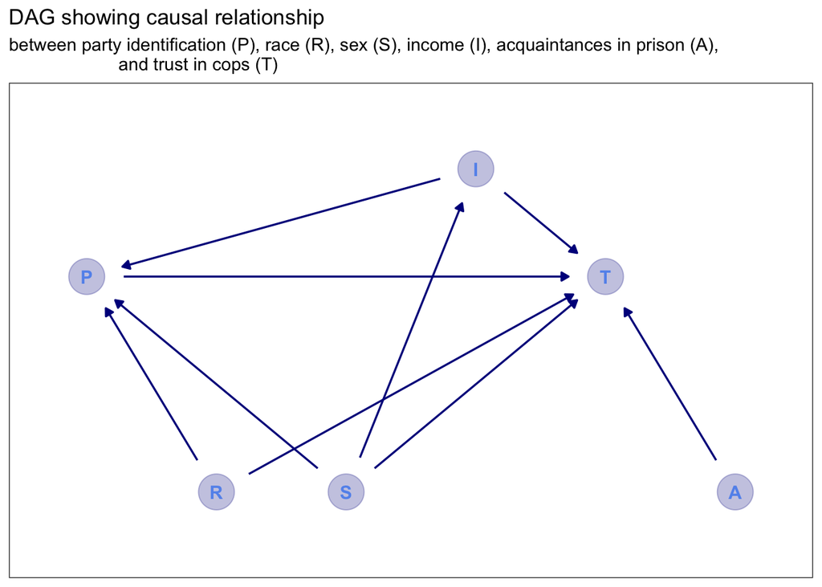

```r
dag_coords <-
  tibble(
    name = c("P", "I", "S", "R", "A", "T"),
    y = c(3, 4, 1, 1, 1, 3),
    x = c(1, 4, 3, 2, 6, 5 )
  )

p1 <-
  dagify(T ~ P, T ~ I, T ~ A, T ~ S, T ~ R, P ~ R, P ~ S, I ~ S, P ~ I,
    coords = dag_coords
  ) %>%
  ggplot(aes(x = x, y = y, xend = xend, yend = yend)) +
  geom_dag_point(color = "blue4", alpha = 1 / 4, size = 10) +
  geom_dag_text(color = "cornflowerblue") +
  geom_dag_edges(edge_color = "blue4") +
  scale_x_continuous(NULL, breaks = NULL, expand = c(0.1, 0.1)) +
  scale_y_continuous(NULL, breaks = NULL, expand = c(0.2, 0.2)) +
  theme_bw() +
  theme(panel.grid = element_blank()) +
  labs(
    title = "DAG showing causal relationship",
    subtitle = paste0("between party identification (P), race (R), sex (S),",
                      " income (I), acquaintances in prison (A),
                      and trust in cops (T)"))

p1
```

I recreated the DAG I made in daggity.net. Here are some of the variables I thought about in the causal structure. Based on this DAG, I will only condition on race, income, and sex (the confounding variables that may create spurious relationships).

3. Now we will create a model and choose priors here.

```r
set.seed(1201)
flist <- alist(
  trtcops ~ dnorm(mu, sigma),
  mu <- a + bP[partyid] + bF * female  + bB * black + bI[income],
  a ~ dnorm (.50, .05),
  # I made trtcops 0/1 to use percentage points
      # is that allowed?
  # 0 = don't trust cops, 1 = trust some amount of cops
  # very high percent of "typical"white men will trust cops
      # is this what alpha represents?
      # how would i read the index variable at 0?
  bP[partyid] ~ dnorm(0, 0.05),
  # I expect the difference between partyid to be one of the highest
  bF ~  dnorm(0, .02),
  # women are likely someone more likely to trust cops more than men
  bB ~ dnorm(0, .03),
  # based on racial profiling and other contextual factors
  # I would expect a pretty significant difference
  # between black people and white people's trust in cops
  bI[income] ~ dnorm(0, .045),
  # I made income an index variable because the variable is coded in categories
  # I feel like there will be a pretty wide spread
  # between the highest and lowest levels of income in their trust of cops
  sigma ~ dexp(1)
)
```

4. Next, we will run a prior predictive simulation like we did in class. We are going to take the real data, and simulate trust in cops (our outcome).

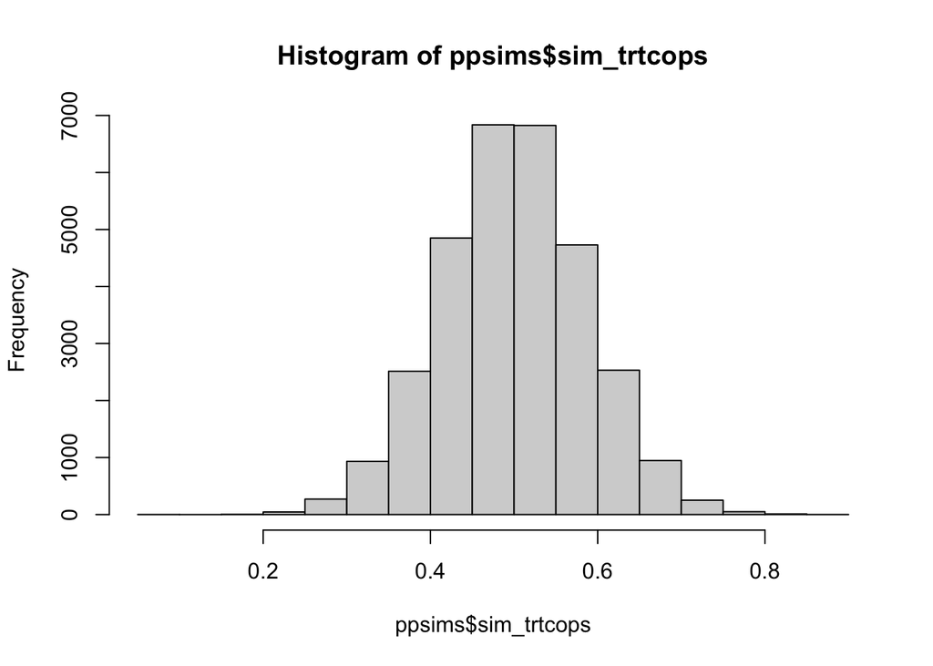

```r
ppsims <- dd %>%
  select(female, black) %>%
  uncount(100) %>%
  rowwise() %>%
  # do this separately for every row, a different random number for every row
  # this will be the same as our equation above, but with simulated stuff
  mutate(sim_trtcops = rnorm(1, 0.50, 0.05) +  #a
          rnorm(1, 0, .05) + # partyid
           rnorm(1, 0, .02) * female +  # bF
           rnorm(1, 0, .03) * black + # bB
           rnorm(1, 0, .045)) #income

# plot the simulated outcome
hist(ppsims$sim_trtcops)
```

That looks pretty good. I’m not sure how to tell when the outcome here is acceptable, but it mirrors what I would have expected based on my priors. Nothing is really below zero or above one and the highest density amount of information falls within 0.4 and approx. 0.6. This makes sense to me as I believe most people in America have a general trust in cops.

Especially after doing some research: https://www.nytimes.com/2020/08/12/us/gallup-poll-police.html\

Basic Summary: Gallup poll found that 48% of Americans trust cops in 2020. However, usually the percentage swings towards the majority.

5. Lastly, I will create the model and finally look at the coeff plot and compare the different effects.

```r
m1 <- quap(flist, data = dd)

precis(m1, depth = 2)
```

```
##                mean         sd        5.5%      94.5%
## a       0.492942398 0.03254509  0.44092906 0.54495574
## bP[1]  -0.013180730 0.04351234 -0.08272185 0.05636039
## bP[2]  -0.001848882 0.04222047 -0.06932534 0.06562758
## bP[3]  -0.023013524 0.04243300 -0.09082966 0.04480261
## bP[4]  -0.030388794 0.04124912 -0.09631286 0.03553527
## bP[5]   0.026613280 0.04418006 -0.04399498 0.09722154
## bP[6]  -0.017720500 0.04048950 -0.08243054 0.04698954
## bP[7]   0.052482907 0.04484379 -0.01918613 0.12415195
## bF     -0.008279634 0.01863577 -0.03806319 0.02150392
## bB     -0.006999668 0.02817965 -0.05203619 0.03803686
## bI[1]   0.008670452 0.04363168 -0.06106139 0.07840230
## bI[2]   0.002440440 0.04300794 -0.06629456 0.07117544
## bI[3]  -0.003115795 0.04411507 -0.07362020 0.06738862
## bI[4]  -0.002612333 0.04378046 -0.07258196 0.06735730
## bI[5]  -0.006951380 0.04394909 -0.07719052 0.06328776
## bI[6]  -0.006547717 0.04395034 -0.07678885 0.06369342
## bI[7]   0.001712018 0.04362685 -0.06801211 0.07143615
## bI[8]  -0.013188772 0.04364619 -0.08294381 0.05656627
## bI[9]  -0.017750289 0.04193556 -0.08477141 0.04927084
## bI[10]  0.003415942 0.04167750 -0.06319275 0.07002463
## bI[11]  0.012582321 0.04155801 -0.05383540 0.07900004
## bI[12]  0.015642042 0.03373802 -0.03827783 0.06956191
## sigma   0.493958280 0.02001910  0.46196390 0.52595266
```

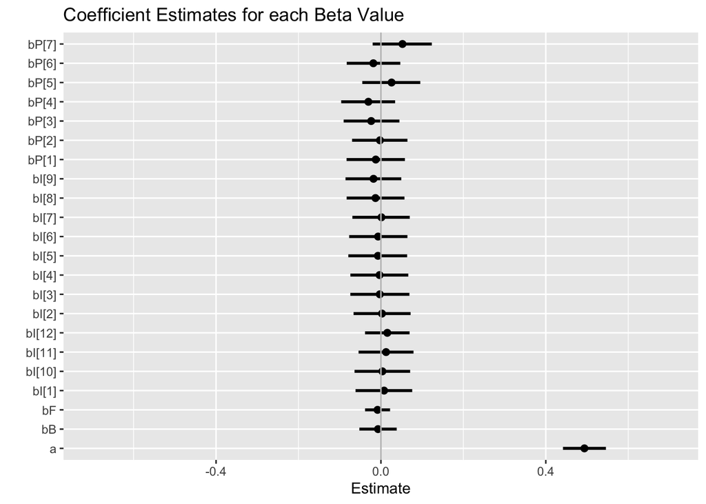

```r
# always take draws from the posterior
post <- tidy_draws(m1, n = 1e4) %>%
  select(-sigma, -.chain, -.iteration, -.draw)
# here we are setting up for our coefficient plot, see page 22 in notes to
# understand how to read a plot... usually we plot different models together to compare
long_post <- post %>%
  pivot_longer(everything(),
    names_to = "term",
    values_to = "values"
  )

postsum <- long_post %>%
  group_by(term) %>%
  summarize(
    mean = mean(values),
    lb = quantile(values, .055),
    ub = quantile(values, .945)
  )


# here is how to plot a coeff plot
ggplot(
  postsum,
  aes(mean, term,
    xmin = lb,
    xmax = ub
  )
) +
  geom_point(size = 2) +
  geom_linerange(size = 1) +
  geom_vline(
    xintercept = 0,
    color = "gray"
  ) +
  theme(legend.position = "none") +
  xlim(-.7, .7) +
  labs(
    x = "Estimate",
    y = "",
    title = "Coefficient Estimates for each Beta Value"
  )
```

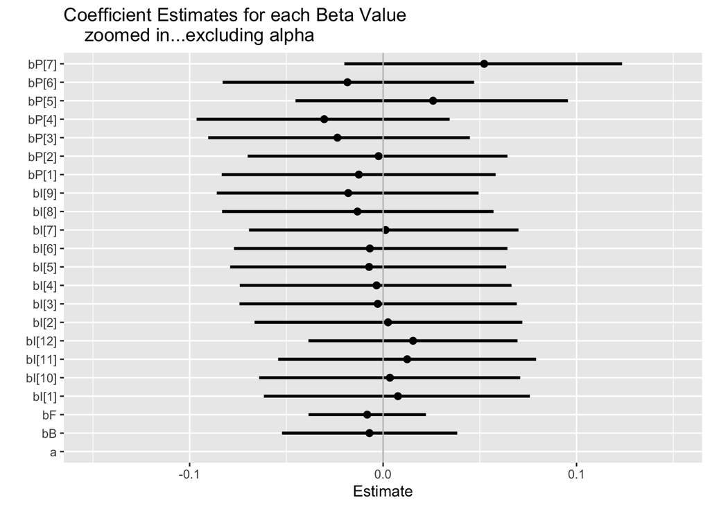

```r
# zoomed in, which cuts off alpha

ggplot(
  postsum,
  aes(mean, term,
    xmin = lb,
    xmax = ub
  )
) +
  geom_point(size = 2) +
  geom_linerange(size = 1) +
  geom_vline(
    xintercept = 0,
    color = "gray"
  ) +
  theme(legend.position = "none") +
  xlim(-.15, .15) +
  labs(
    x = "Estimate",
    y = "",
    title = "Coefficient Estimates for each Beta Value
    zoomed in...excluding alpha"
  )
```

bB (race) and bF (sex) have a small negative effect on trust in cops.

bP[1-3] are all levels of democrats (including independent close to democrat) and they all seem to have a negative effect with trust in cops. bP[4] is straight independent and this also has a negative effect on trust in cops. bP[6] is not very strong republican and there is still a negative effect on trust in cops. People who identify as strong republicans, bP[7], or as independent, close to republican, bP[5], were the only groups (for this variable) that showed positive effects on trust in cops.

6. Now I will attempt to plot a posterior distribution of a linear model against data with uncertainty. I am not sure if having a coeff plot is enough… I realized I don’t know if a coeff plot ACTUALLY answers my original estimand. I’m not sure at what point I have enough information to address my estimand. Interesting. Hopefully you can help me with this. <3
- I realized I got confused for using the posterior predictive check using ggplot because when it came to the slopes there was more than one and that became confusing so below is me playing around with new ways to try to plot. Not sure if possible but wanted to try.

```r
m2 <- lm(trtcops ~ partyid + female + black + income , data = dd)
precis(m2)
```

```
##                     mean          sd         5.5%      94.5%
## (Intercept)  0.384953631 0.126441542  0.182875626 0.58703164
## partyid      0.023142839 0.015823735 -0.002146545 0.04843222
## female      -0.066575588 0.057873107 -0.159067990 0.02591681
## black       -0.018198888 0.087318352 -0.157750480 0.12135270
## income       0.004761297 0.009152678 -0.009866450 0.01938904
```

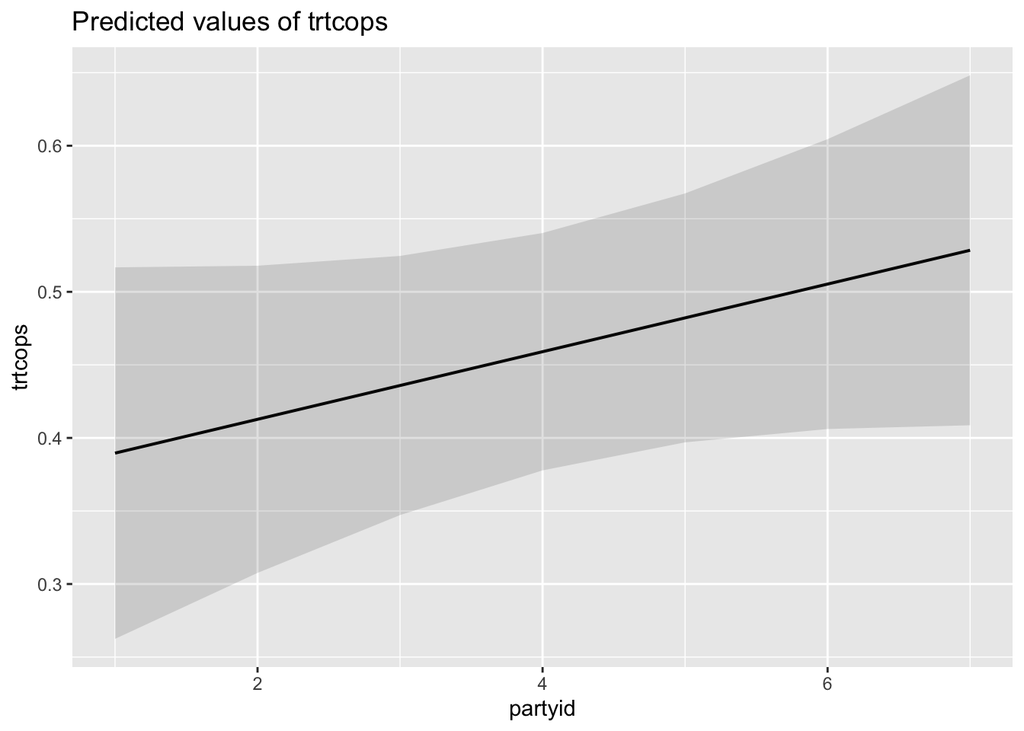

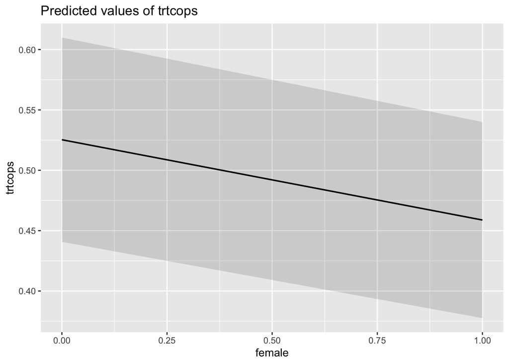

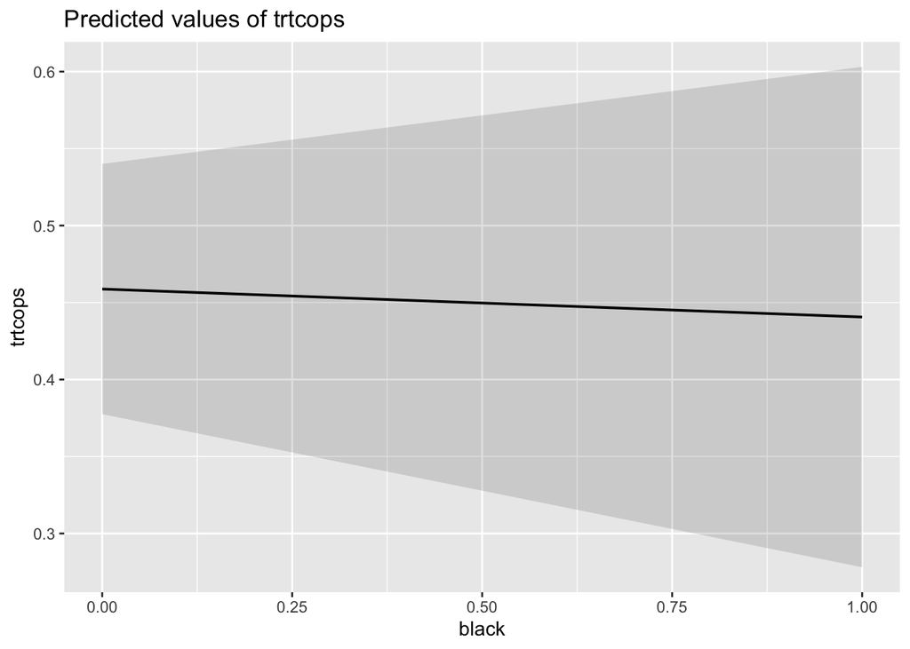

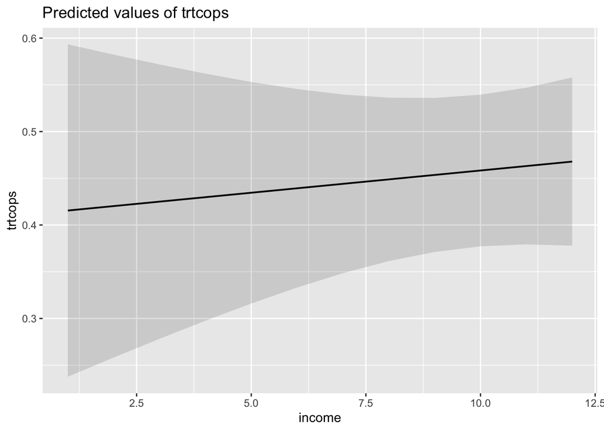

```r
library(sjPlot)
library(car)
library(ggplot2)
# I just tried this one and these seem pretty promising... hmmmm :)
plot_model(m2, type = "pred")
```

```r
 # plot_model(m2, type = "eff", terms = "partyid")

# not really sure what the differences are
  # seemed to make the same graph so I made it a comment
# I read over the description but pretty confusing for where I am currently
```

Well… I have some issues with this and I don’t know why. (these comments are related to m2 summary)

1. Why are `black` and `female`’s values doing is this way different than when I did it the other way?
2. Why is there only one `partyid` and `income` effect?

I can’t figure out how to make `partyid` or `income` index variables inside of the `lm` function. Should I have stopped at the coeff plots? Also, I don’t know what the other plots (besides the one that looks like a coeff plot) is showing me but I wanted to see if i could graph SOMETHING. :’(

Well, sorry for the let down here at the end. I did my best. :) Looking forward to your feedback.

Safe travels and good luck on your next endeavors my friend.

Ally :’)